# 第1课 R Studio入门 习题答案

顶刊研习社

Li Zongzhang

2023-10-17

# 1 习题1

1.1 创建一个项目，在该项目中创建一个代码文件。

略

1.2 调用R自带的数据框airquality。

```r
data(airquality)
```

1.3 查看airquality数据框的帮助文档。

```r
?airquality
```

1.4 airquality数据框有多少行？有多少列？

153行，6列。

```r
#查看数据框的结构
str(airquality)
```

```
'data.frame':   153 obs. of  6 variables:
 $ Ozone  : int  41 36 12 18 NA 28 23 19 8 NA ...
 $ Solar.R: int  190 118 149 313 NA NA 299 99 19 194 ...
 $ Wind   : num  7.4 8 12.6 11.5 14.3 14.9 8.6 13.8 20.1 8.6 ...
 $ Temp   : int  67 72 74 62 56 66 65 59 61 69 ...
 $ Month  : int  5 5 5 5 5 5 5 5 5 5 ...
 $ Day    : int  1 2 3 4 5 6 7 8 9 10 ...
```

```r
#dim()函数查看数据框的维度
dim(airquality)
```

```
[1] 153   6
```

1.5 计算airquality数据框中的Temp的均值、中位数、标准差、最大值、最小值、四分位数。

```r
mean(airquality$Temp)
```

```
[1] 77.88235
```

```r
median(airquality$Temp)
```

```
[1] 79
```

```r
sd(airquality$Temp)
```

```
[1] 9.46527
```

```r
max(airquality$Temp)
```

```
[1] 97
```

```r
min(airquality$Temp)
```

```
[1] 56
```

```r
quantile(airquality$Temp)
```

```
  0%  25%  50%  75% 100%
  56   72   79   85   97
```

```r
temp_mean <- mean(airquality$Temp)
temp_mean
```

```
[1] 77.88235
```

```r
temp_median <- median(airquality$Temp)
temp_median
```

```
[1] 79
```

```r
temp_sd <- sd(airquality$Temp)
temp_sd
```

```
[1] 9.46527
```

1.7 用summary()函数查看airquality数据框的描述性统计量。

```r
summary(airquality$Temp)
```

```
   Min. 1st Qu.  Median    Mean 3rd Qu.    Max.
  56.00   72.00   79.00   77.88   85.00   97.00
```

1.8 用psych包下的describe函数查看airquality数据框的描述性统计量。

```r
psych::describe(airquality$Temp)
```

```
   vars   n  mean   sd median trimmed mad min max range  skew kurtosis   se
X1    1 153 77.88 9.47     79   78.28 8.9  56  97    41 -0.37    -0.46 0.77
```

1.9 用boxplot()函数画出airquality数据框中的Temp的箱线图。

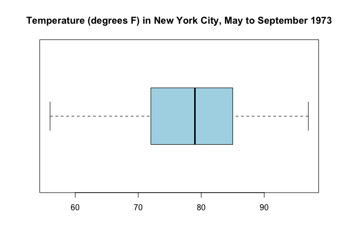

```r
boxplot(airquality$Temp,
        col = "lightblue",
        horizontal = TRUE,
        main = "Temperature (degrees F) in New York City, May to September 1973"
        )
```

1.10 用hist()函数画出airquality数据框中的Temp的直方图。将改图片保存在项目路径下。

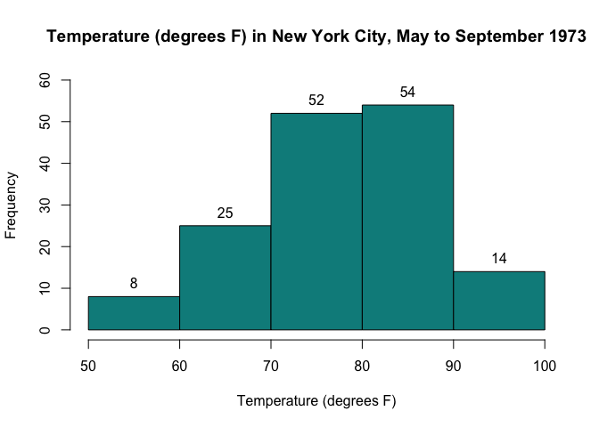

```r
hist(airquality$Temp,
     breaks = c(50, 60, 70, 80, 90, 100),
     col = "cyan4",
     border = "black",
     xlab = "Temperature (degrees F)",
     ylab = "Frequency",
     main = "Temperature (degrees F) in New York City, May to September 1973",
     xlim = c(50, 100),
     ylim = c(0, 60)
     )

# 获取直方图的数据
hist_data <- hist(airquality$Temp,
                  breaks = c(50, 60, 70, 80, 90, 100),
                  plot = FALSE)

# 在直方图上标注频数
text(x = hist_data$mids, y = hist_data$counts,
     labels = hist_data$counts, pos = 3, col = 1)
```

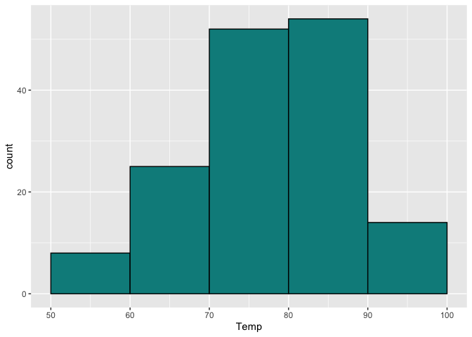

```r
#保存图片

# 在plots窗口，单击Export按钮，选择Save as Image，保存图片


# 通过ggplot2绘图，然后用ggsave()保存
library(tidyverse)
airquality %>%
  ggplot(aes(Temp)) +
  geom_histogram(breaks = c(50, 60, 70, 80, 90, 100),
            col = "black",
            fill = "cyan4")
```

```r
#保存图片
ggsave("hist_temp.png", width = 6, height = 4, dpi = 300)
```

1.11 用plot()函数画出airquality数据框中的Temp和Ozone的散点图。

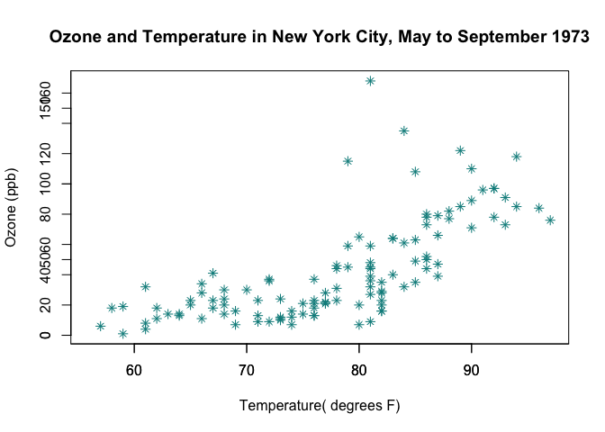

```r
plot(airquality$Temp, airquality$Ozone,
     main = "Ozone and Temperature in New York City, May to September 1973",
     xlab = "Temperature( degrees F)",
     ylab = "Ozone (ppb)",
     pch = 8,
     col = "cyan4")
axis(1, at = seq(50, 100, by = 10))  # 自定义X轴刻度
axis(2, at = seq(0, 200, by = 20))    # 自定义Y轴刻度
```

1.12 将airquality数据框导出为一个Excel文件。

```r
# install.packages("writexl")
library(writexl)
# 导出的Exel文件放在项目/工作路径中，否则需要写出完整路径
write_xlsx(airquality, "airquality.xlsx")
```

1.13 导入一个你自己的Excel文件，从history中复制你的代码到你的R代码文件中。

略

1.14 用psych::describe()函数查看你导入的数据框的描述性统计量。

略

1.15 安装并加载包tidyverse。运行library(tidyverse)后，在Console中会显示tidyverse包中包含的包, 代表安装成功

```r
#install.packages("tidyverse")
library(tidyverse)
```